# R爬蟲教學

Lin

2019/12/4

### 在準備爬網前，必須先了解網⾴整體的架構，所以⾸先讓我們進⼊PTT⼋卦版⾸⾴

[八卦版](https://www.ptt.cc/bbs/Gossiping/index.html)

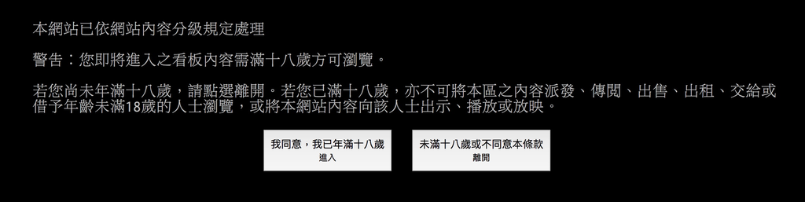

### 由上圖可看到⼀開始進⼊PTT⼋卦版⾴⾯時，會有⼀個是否年滿 18 歲的驗證⾴⾯，按下我同意後才會進⼊⼋卦版⽂章的⾸⾴，畫⾯如下

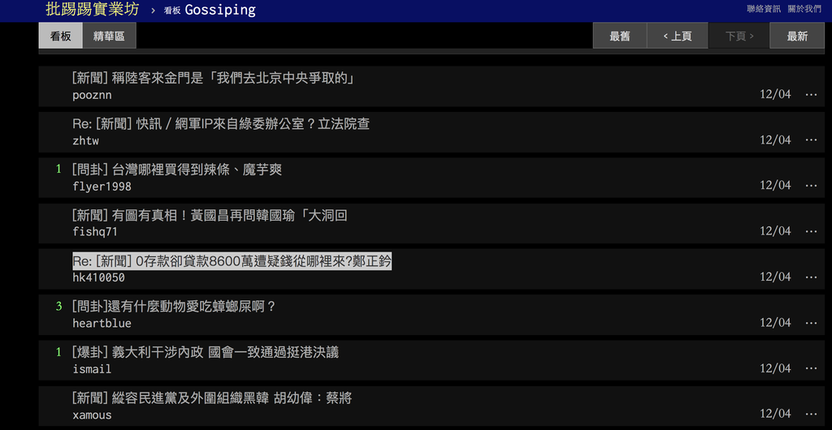

### 那要怎麼樣利⽤R軟體的程式執⾏驗證的⾴⾯呢?⾸先準備好要使⽤的套件並引⼊

```r
library(tidyverse)
library(rvest)
library(stringr)
library(jiebaR)
library(tmcn)
library(wordcloud2)
jieba.worker <- worker()
```

- tidyverse: 內含資料處理套件(dplyr)和繪圖套件(ggplot2)等
- rvest: 網⾴解析處理套件
- stringr: 字串處理套件
- jiebaR: ⽂字斷詞
- tmcn: ⽂字字庫
- wordcloud2: 文字雲

### 將PTT網址設定好使⽤ html_session 讀取並存為 gossiping.session

```r
ptt.url <- "https://www.ptt.cc"
gossiping.url <- paste(ptt.url,"/bbs/Gossiping",sep = "")
gossiping.url
```

```
## [1] "https://www.ptt.cc/bbs/Gossiping"
```

```r
gossiping.session <- html_session(url = gossiping.url)
gossiping.session
```

```
## <session> https://www.ptt.cc/ask/over18?from=%2Fbbs%2FGossiping%2Findex.html
##   Status: 200
##   Type:   text/html; charset=utf-8
##   Size:   2411
```

### 可看到 url 指定⼋卦版的連結，但由於是初始進⼊⽽被導向⾄認證⾴⾯，所以在 gossiping.session的上⽅連結才會是認證⾴⾯的連結。

## 接下來的步驟如下

### 1. 找到認證的表單(form)

```r
gossiping.form <- gossiping.session %>%
 html_node("form") %>%
 html_form()
gossiping.form
```

```
## <form> '<unnamed>' (POST /ask/over18)
##   <input hidden> 'from': /bbs/Gossiping/index.html
##   <button submit> 'yes
##   <button submit> 'no
```

### 2.填上確認數值(yes)

```r
gossiping <- submit_form(
 session = gossiping.session,
 form = gossiping.form,
 submit = "yes")
gossiping
```

```
## <session> https://www.ptt.cc/bbs/Gossiping/index.html
##   Status: 200
##   Type:   text/html; charset=utf-8
##   Size:   20792
```

### 可看到在提交確認表單後，gossiping的連結已改變為⼋卦版⾸⾴，此時我們可以先進⼊⼋卦版⾸⾴看⼀下整體網⾴架構，⽽觀看原始碼的⽅式只需在⾴⾯空⽩處按右鍵並點選檢視網⾴原始碼，如下圖

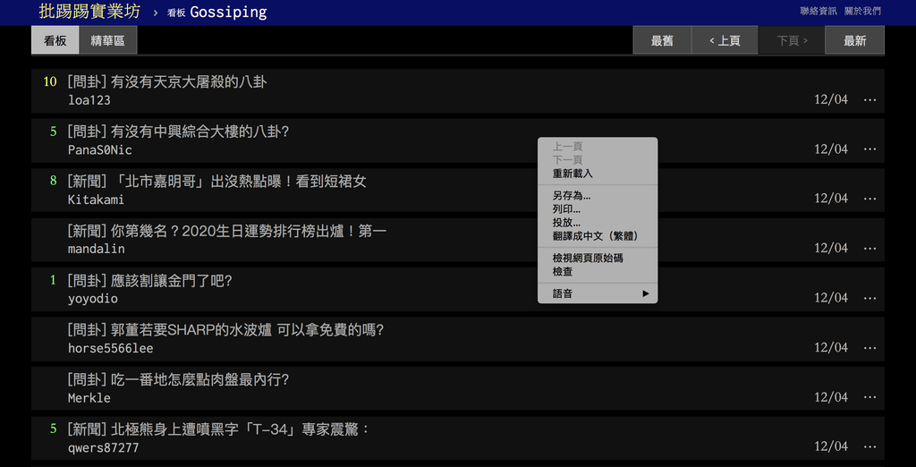

### 點選檢查網頁原始碼後原始碼⾴⾯如下

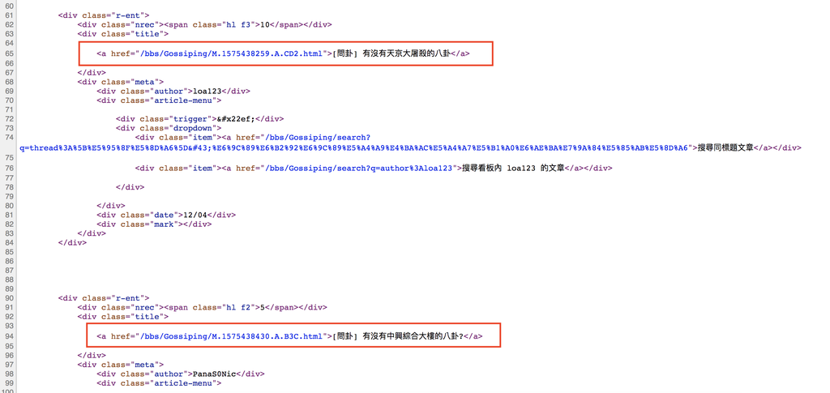

### 上圖紅⾊框內的元素就是下圖網⾴上標題的部份

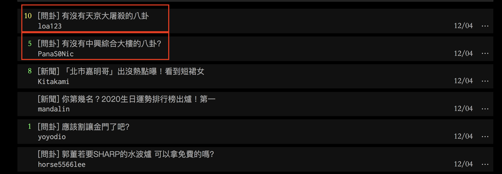

```r
page.latest <- gossiping %>%
 html_nodes("a") %>%
 html_attr("href") %>%
 str_subset("index[0-9]{2,}\\.html") %>%
 str_extract("[0-9]+") %>%
 as.numeric()
page.latest
```

```
## [1] 39022
```

#### page.latest 是最新⾴碼數字，必須從主⾴ gossiping 裡去尋找步驟依序如下

- html_nodes(“a”): 擷取所有 a 元素
- html_attr(“href”): 擷取 a 元素裡的 href 屬性也就是該連結網址
- str_subset(“index[0-9]{2,}\.html”): 篩選符合 index 後⾯接⼀串數字的連結
- str_extract(“[0-9]+”): 擷取連結內數字的部分
- as.numeric(): 轉換為數字格式

#### 得到最新的⾴碼數 page.latest 後，利⽤迴圈的⽅式對每⼀⾴做⽂章連結的收集

```r
links.article <- NULL
page.length <- 30
for (page.index in page.latest:(page.latest - page.length)) {
 link <- str_c(gossiping.url, "/index", page.index, ".html")
 print(link)
 links.article <- c(
 links.article,
 gossiping %>%
 jump_to(link) %>%
 html_nodes("a") %>%
 html_attr("href") %>%
 str_subset("[A-z]\\.[0-9]+\\.[A-z]\\.[A-z0-9]+\\.html")
)
}
```

```
## [1] "https://www.ptt.cc/bbs/Gossiping/index39022.html"
## [1] "https://www.ptt.cc/bbs/Gossiping/index39021.html"
## [1] "https://www.ptt.cc/bbs/Gossiping/index39020.html"
## [1] "https://www.ptt.cc/bbs/Gossiping/index39019.html"
## [1] "https://www.ptt.cc/bbs/Gossiping/index39018.html"
## [1] "https://www.ptt.cc/bbs/Gossiping/index39017.html"
## [1] "https://www.ptt.cc/bbs/Gossiping/index39016.html"
## [1] "https://www.ptt.cc/bbs/Gossiping/index39015.html"
## [1] "https://www.ptt.cc/bbs/Gossiping/index39014.html"
## [1] "https://www.ptt.cc/bbs/Gossiping/index39013.html"
## [1] "https://www.ptt.cc/bbs/Gossiping/index39012.html"
## [1] "https://www.ptt.cc/bbs/Gossiping/index39011.html"
## [1] "https://www.ptt.cc/bbs/Gossiping/index39010.html"
## [1] "https://www.ptt.cc/bbs/Gossiping/index39009.html"
## [1] "https://www.ptt.cc/bbs/Gossiping/index39008.html"
```

[output cut: 16 more lines]

#### links.article 為存放⽂章連結的空間，page.length 為想要存放的⾴數，迴圈內容如下

- link: 當下迴圈輪到的連結
- jump_to(link): 跳⾴⾄新⾴⾯
- html_nodes(“a”) & html_attr(“href”): 找 a 元素的 href 屬性
- str_subset(“[A-z]\.[0-9]+\.[A-z]\.[A-z0-9]+\.html”):篩選符合⽂章連結格式的連結

### 為了避免連結重複⽤ unique 重新做處理

```r
links.article <- unique(links.article)
head(links.article,20)
```

```
##  [1] "/bbs/Gossiping/M.1576038208.A.528.html"
##  [2] "/bbs/Gossiping/M.1576038282.A.F9A.html"
##  [3] "/bbs/Gossiping/M.1576038410.A.032.html"
##  [4] "/bbs/Gossiping/M.1576038414.A.12F.html"
##  [5] "/bbs/Gossiping/M.1576038419.A.3F9.html"
##  [6] "/bbs/Gossiping/M.1576038475.A.ED0.html"
##  [7] "/bbs/Gossiping/M.1576038498.A.842.html"
##  [8] "/bbs/Gossiping/M.1576038504.A.0A5.html"
##  [9] "/bbs/Gossiping/M.1576038542.A.4F2.html"
## [10] "/bbs/Gossiping/M.1576038546.A.236.html"
## [11] "/bbs/Gossiping/M.1576038564.A.A2B.html"
## [12] "/bbs/Gossiping/M.1576038577.A.254.html"
## [13] "/bbs/Gossiping/M.1576038587.A.6CD.html"
## [14] "/bbs/Gossiping/M.1576038601.A.7FC.html"
## [15] "/bbs/Gossiping/M.1576038613.A.8BA.html"
## [16] "/bbs/Gossiping/M.1576038614.A.7B2.html"
## [17] "/bbs/Gossiping/M.1576038659.A.136.html"
## [18] "/bbs/Gossiping/M.1576038739.A.D27.html"
## [19] "/bbs/Gossiping/M.1576038937.A.B77.html"
## [20] "/bbs/Gossiping/M.1576037386.A.775.html"
```

### 經過以上迴圈處理後得到每⼀⾴內的⽂章連結 links.article，接下來進⼊ links.article 內各連結即可爬⽂

```r
article.table <- tibble() # 建⽴⽂章儲存空間
for (temp.link in links.article) {
 article.url <- str_c(ptt.url, temp.link) # ⽂章網址
 temp.html <- gossiping %>% jump_to(article.url) # 連結⾄⽂章網址
 article.header <- try(temp.html %>%
 html_nodes("span.article-meta-value") %>% # 開頭部分元素
 html_text())
 article.author <- article.header[1] %>% str_extract("^[A-z0-9_]+") # 作者
 article.title <- article.header[3] # 標題
 article.datetime <- article.header[4] # 時間
 article.content <- try(temp.html %>%
 html_nodes( # 內⽂部分
 xpath = '//div[@id="main-content"]/node()[not(self::div|self::span[@class="f2"])]'
 ) %>%
 html_text(trim = TRUE) %>%
 str_c(collapse = ""))
 article.table <- article.table %>% # 合併⽂章資料
 bind_rows(
 tibble(
 datetime = article.datetime,
 title = article.title,
 author = article.author,
 content = article.content,
 url = article.url
 )
)
}
article.table <- article.table %>% # 格式整理清除 NA
 mutate(
 datetime = str_sub(datetime, 5) %>% parse_datetime("%b %d %H:%M:%S %Y"),
 month = format(datetime, "%m"),
 day = format(datetime, "%d")
 ) %>%
 filter_all(
 all_vars(!is.na(.))
 )
```

### 經過以上步驟，可得到內文資料

- article.table: ⽂章資料(標題、作者、時間、內⽂)

```r
jieba.worker <- worker()
```

## jieba 是⼀個斷詞⼯具，內有segment函數可以使⽤，有了斷詞⼯具後就可以來對每天⼋卦版的⽂章內容做斷詞，如下

```r
new_user_word(jieba.worker, c("柯文哲","韓國瑜","郭台銘","蔡英文","發大財"))
```

```
## [1] TRUE
```

```r
article.date <- article.table %>%
  group_by(day,month) %>% # 以每⽇做分組
  do((function(input) {
    freq(segment(as.character(input$content), jieba.worker)) %>% # 斷詞後計算詞頻
      filter(
        !(char %in% toTrad(stopwordsCN())), # 過濾 stopword
        !str_detect(char, "[A-z0-9]"), # 過濾英⽂數字
        nchar(char) > 1 # 過濾單個字
      ) %>%
      arrange(desc(freq)) %>% # 以詞頻排序
      slice(1:100) %>% # 取前 100
      return})(.)) %>%
  ungroup
article.date.words <- freq(article.date$char) %>%
  rename(freq.all = freq)
article.date
```

[output not shown]

### 最後可得每⽇出現最多次前 100 名的詞，我們藉此統計並過濾出每⽇特有的詞最後當⽇的前 5 ⼤代表詞，程式如下

```r
article.everyday <- article.date %>%
 left_join( # ⽐對全部詞
 article.date.words,
 by = 'char'
 ) %>%
 group_by(day,month) %>% # 以每⽇做分組
 arrange(freq.all) %>% # 每組的詞頻做排序由⼩到⼤
 slice(1:5) %>% # 取每組前 5
 summarise( # 合併詞並對詞頻加總
 char = str_c(char, collapse = ", "),
 freq = sum(freq)
 ) %>%
 ungroup
article.everyday
```

[output not shown]

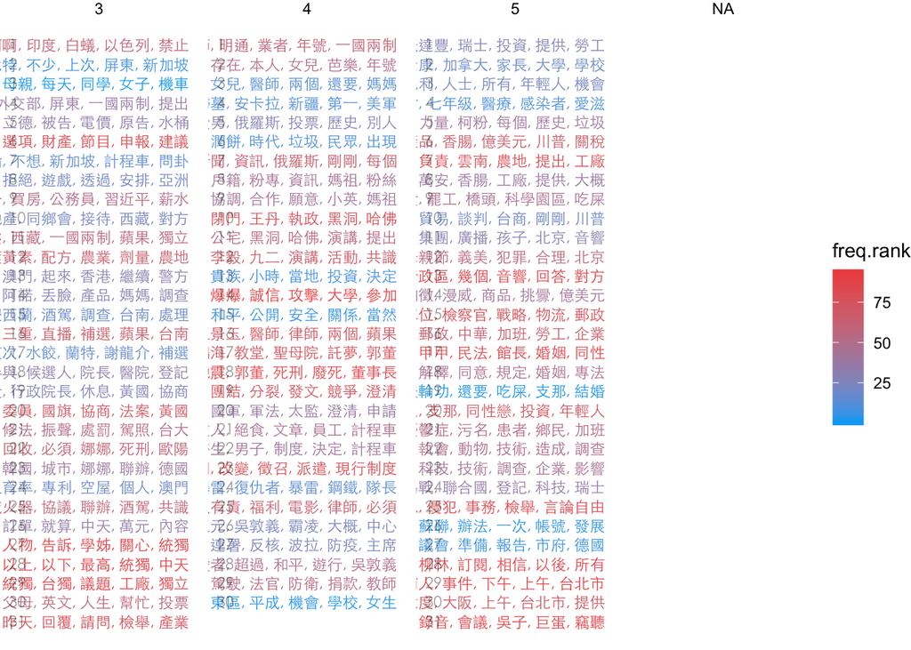

```r
article.everyday %>%  as.data.frame() %>%
  mutate( # 計算⽉⽇和頻率排名
#    month = str_c(format(date, "%m"), "⽉"),
#    day = format(date, "%d") %>% parse_number(),
    freq.rank = rank(freq)
  )  %>%
  ggplot() +
  geom_text(
    aes(x = 1,
        y = as.numeric(day),
        label = char,
        color = freq.rank
    ),
    hjust = 1,
    size = 3,
    family="黑體-繁 細體"
  ) +
  geom_text(
    aes(
      x = 0,
      y = as.numeric(day),
      label = as.numeric(day)#format(date, "%d")
    ),
    hjust = 0,
    size = 3,
    alpha = 0.4,
    family="黑體-繁 細體"
  ) +
  scale_color_continuous(low = "#03A9F4", high = "#EF5350") +
  scale_y_reverse() +
  facet_grid( ~ as.numeric(month)) +
  theme_void()
```

### 最後畫一個文字雲

```r
article.date2 =  article.date %>% group_by(char) %>% summarise(freq=sum(freq))
wordcloud2(article.date2,size = 0.5,shape = "diamond")
```

[interactive chart not shown]